# DV_RProject3

## DV_RProject3

#### Group member: Anna Mengjie Yu (my3852), Duy Vu (dhv242), Syed Naqvi (san724)

With the advent of next generation sequencing, the sequencing cost per genome is decreasing significantly. Gene content and gene order has been useful in studying species evolution and ecological adaptation. Good data visualization tools will help community better understand the evolution story underneath the data. In this project, we will be using diatom plastid genome data from several diatom species. Each species may or may not share the same gene content due to environment selection. Difference tables can be joined by the gene names.

The tables contain plastid genome gene content, gene length and gene order, and they are accessible from Supporting Information in Yu's publicaiton. [http://journals.plos.org/plosone/article?id=10.1371/journal.pone.0107854]

Load packages

```r
source("../01 Data/loadPackage.R", echo = TRUE)
```

```
##
## > require("ggplot2")
```

```
##
## > require("gplots")
```

```
##
## > require("grid")
```

```
##
## > require("RCurl")
```

```
##
## > require("reshape2")
```

```
##
## > require("tidyr")
```

```
##
## > require("dplyr")
```

```
##
## > require("jsonlite")
```

First, we displayed a few lines of the dataset stored in oracle database. The table includes Name(gene name), MINIMUM (gene start position), MAXIMUM(gene end position), LENGTH(gene length), DIRECTION(sense and anti-sense strand).

This table is loaded in project2, JSON makes error in getting the table, we appreciate Dr. Cannata agreed us to use the previous method to get this table.

**Table 1: Cyclotella**

```r
source("../01 Data/cyclotella.R", echo = TRUE)
```

```
##
## > cyclotella <- data.frame(eval(parse(text = substring(getURL(URLencode("http://129.152.144.84:5001/rest/native/?query=\"select * from cyclotella\""), .... [TRUNCATED]
##
## > cyclotella %>% tbl_df
## Source: local data frame [180 x 5]
##
##              NAME MINIMUM MAXIMUM LENGTH DIRECTION
## 1       psaA gene     103   2,361  2,259   forward
## 2       psaB gene   2,478   4,679  2,202   forward
## 3       petF gene   4,912   5,244    333   reverse
## 4      rpl20 gene   5,425   5,844    420   reverse
## 5      rpl35 gene   5,854   6,048    195   reverse
## 6      ycf42 gene   6,055   6,690    636   reverse
## 7       psaE gene   6,792   6,989    198   reverse
## 8  trnR(ucu) gene   7,154   7,226     73   reverse
## 9  trnV(uac) gene   7,237   7,308     72   reverse
## 10      psbH gene   7,575   7,775    201   reverse
## ..            ...     ...     ...    ...       ...
```

**Table 2: Thalassiosira weissflogii**

Thalassiosira weissflogii is a closely related species to Cyclotella. They both belong to the same Thalassiosirales family.

```r
source("../01 Data/weiss.R", echo = TRUE)
```

```
##
## > weiss <- data.frame(fromJSON(getURL(URLencode("129.152.144.84:5001/rest/native/?query=\"select * from weiss\""),
## +     httpheader = c(DB = "jdbc:or ..." ... [TRUNCATED]
##
## > weiss %>% tbl_df
## Source: local data frame [180 x 5]
##
##              NAME MINIMUM MAXIMUM LENGTH DIRECTION
## 1      rpl32 gene 120,353 120,517    165   reverse
## 2       psbY gene 120,762 120,872    111   reverse
## 3       rrn5 rRNA 121,057 121,182    126   reverse
## 4             rns 121,332 124,090  2,759   reverse
## 5   trnA-UGC gene 124,179 124,251     73   reverse
## 6   trnI-GAU gene 124,254 124,327     74   reverse
## 7             rnl 124,384 125,860  1,477   reverse
## 8      ycf89 gene 126,149 127,111    963   reverse
## 9  trnP(ugg) gene 127,458 127,531     74   forward
## 10      psaA gene     142   2,400  2,259   forward
## ..            ...     ...     ...    ...       ...
```

**Table 3: Cerataulina daemon**

Cerataulina daemon is more closely related to Chaetoros simplex than the two Thalassiosirales.

```r
source("../01 Data/cerataulina.R", echo = TRUE)
```

```
##
## > cera <- data.frame(fromJSON(getURL(URLencode("129.152.144.84:5001/rest/native/?query=\"select * from cerataulina\""),
## +     httpheader = c(DB = "jd ..." ... [TRUNCATED]
##
## > cera %>% tbl_df
## Source: local data frame [169 x 5]
##
##             NAME MINIMUM MAXIMUM LENGTH DIRECTION
## 1      psaA gene     362   2,620  2,259   forward
## 2      psaB gene   2,712   4,913  2,202   forward
## 3  trnD-GUC gene   5,037   5,110     74   reverse
## 4  trnS-GCU gene   5,175   5,260     86   reverse
## 5  trnI-CAU gene   5,298   5,369     72   reverse
## 6     ycf33 gene   5,546   5,740    195   forward
## 7  trnY-GUA gene   7,698   7,780     83   reverse
## 8  trnV-UAC gene   8,306   8,371     66   forward
## 9  trnR-UCU gene   8,383   8,455     73   forward
## 10     trnT(ugu)   8,768   8,839     72   reverse
## ..           ...     ...     ...    ...       ...
```

**Table 4: Chaetoceros simplex**

```r
source("../01 Data/chaetoceros.R", echo = TRUE)
```

```
##
## > chaeto <- data.frame(fromJSON(getURL(URLencode("129.152.144.84:5001/rest/native/?query=\"select * from chaetoceros\""),
## +     httpheader = c(DB = " ..." ... [TRUNCATED]
##
## > chaeto %>% tbl_df
## Source: local data frame [169 x 5]
##
##              NAME MINIMUM MAXIMUM LENGTH DIRECTION
## 1      ycf45 gene       2   1,168  1,167   reverse
## 2       petD gene   1,330   1,812    483   reverse
## 3       petB gene   1,865   2,512    648   reverse
## 4   trnS-UGA gene   2,571   2,657     87   reverse
## 5       psaD gene   2,690   3,109    420   reverse
## 6  trnfM-CAU gene   3,195   3,266     72   reverse
## 7       rps2 gene   3,388   4,071    684   reverse
## 8      rpoC2 gene   4,159   8,406  4,248   reverse
## 9      rpoC1 gene   8,435  10,840  2,406   reverse
## 10      rpoB gene  10,858  15,099  4,242   reverse
## ..            ...     ...     ...    ...       ...
```

**Table 5: Thalassiosira oceanica**

```r
source("../01 Data/ocean.R", echo = TRUE)
```

```
##
## > ocean <- data.frame(fromJSON(getURL(URLencode("129.152.144.84:5001/rest/native/?query=\"select * from ocean\""),
## +     httpheader = c(DB = "jdbc:or ..." ... [TRUNCATED]
```

**Data Wrangling 1**

1.For each original table, create new column gene_family by extracting the first three charaters from gene NAME, and further group by gene family.

```r
source("../02 Data Wrangling/geneFamily.R", echo = TRUE)
```

```
##
## > cyc_gf <- cyclotella %>% mutate(gene_family = substr(NAME,
## +     1, 3)) %>% group_by(gene_family)
##
## > cyc_gf %>% tbl_df
## Source: local data frame [180 x 6]
##
##              NAME MINIMUM MAXIMUM LENGTH DIRECTION gene_family
## 1       psaA gene     103   2,361  2,259   forward         psa
## 2       psaB gene   2,478   4,679  2,202   forward         psa
## 3       petF gene   4,912   5,244    333   reverse         pet
## 4      rpl20 gene   5,425   5,844    420   reverse         rpl
## 5      rpl35 gene   5,854   6,048    195   reverse         rpl
## 6      ycf42 gene   6,055   6,690    636   reverse         ycf
## 7       psaE gene   6,792   6,989    198   reverse         psa
## 8  trnR(ucu) gene   7,154   7,226     73   reverse         trn
## 9  trnV(uac) gene   7,237   7,308     72   reverse         trn
## 10      psbH gene   7,575   7,775    201   reverse         psb
## ..            ...     ...     ...    ...       ...         ...
##
## > weiss_gf <- weiss %>% mutate(gene_family = substr(NAME,
## +     1, 3)) %>% group_by(gene_family)
##
## > weiss_gf %>% tbl_df
## Source: local data frame [180 x 6]
##
##              NAME MINIMUM MAXIMUM LENGTH DIRECTION gene_family
## 1      rpl32 gene 120,353 120,517    165   reverse         rpl
## 2       psbY gene 120,762 120,872    111   reverse         psb
## 3       rrn5 rRNA 121,057 121,182    126   reverse         rrn
## 4             rns 121,332 124,090  2,759   reverse         rns
## 5   trnA-UGC gene 124,179 124,251     73   reverse         trn
## 6   trnI-GAU gene 124,254 124,327     74   reverse         trn
## 7             rnl 124,384 125,860  1,477   reverse         rnl
## 8      ycf89 gene 126,149 127,111    963   reverse         ycf
## 9  trnP(ugg) gene 127,458 127,531     74   forward         trn
## 10      psaA gene     142   2,400  2,259   forward         psa
## ..            ...     ...     ...    ...       ...         ...
##
## > cera_gf <- cera %>% mutate(gene_family = substr(NAME,
```

[output cut: 40 more lines]

```
## > ocean_gf %>% tbl_df
## Source: local data frame [185 x 6]
##
##           NAME START_POS END_POS LENGTH DIRECTION gene_family
## 1     psaA CDS       122    2380   2259   forward         psa
## 2     psaB CDS      2484    4685   2202   forward         psa
## 3    trnV tRNA      5389    5460     72   forward         trn
## 4  trnR-2 tRNA      5480    5552     73   forward         trn
## 5   orf127 CDS      6165    6587    423   reverse         orf
## 6    rpl19 CDS      7142    7504    363   reverse         rpl
## 7  trnM-2 tRNA      7591    7675     85   reverse         trn
## 8   ssra tmRNA      7680    8013    334   reverse         ssr
## 9  trnR-1 tRNA      8072    8144     73   reverse         trn
## 10    atpA CDS      9008   10519   1512   reverse         atp
## ..         ...       ...     ...    ...       ...         ...
```

**Data Wrangling 2**

```r
source("../02 Data Wrangling/cyc_FR.R", echo = TRUE)
```

```
##
## > cyc_gf_forward <- filter(cyc_gf, DIRECTION == "forward")
##
## > cyc_gf_forward %>% tbl_df
## Source: local data frame [107 x 6]
##
##              NAME MINIMUM MAXIMUM LENGTH DIRECTION gene_family
## 1       psaA gene     103   2,361  2,259   forward         psa
## 2       psaB gene   2,478   4,679  2,202   forward         psa
## 3       psbN gene   7,860   7,991    132   forward         psb
## 4       rbcL gene  16,918  18,390  1,473   forward         rbc
## 5       rbcS gene  18,429  18,848    420   forward         rbc
## 6       psbX gene  19,138  19,254    117   forward         psb
## 7      ycf66 gene  19,444  19,752    309   forward         ycf
## 8       psbV gene  19,806  20,297    492   forward         psb
## 9  trnR(ccg) gene  20,396  20,467     72   forward         trn
## 10      ssra gene  20,522  20,868    347   forward         ssr
## ..            ...     ...     ...    ...       ...         ...
##
## > cyc_gf_forwardNum <- cyc_gf_forward %>% group_by(gene_family) %>%
## +     summarise(forward_gene_num = n())
##
## > cyc_gf_forwardNum
## Source: local data frame [22 x 2]
##
##    gene_family forward_gene_num
## 1          atp                2
## 2          cbb                1
## 3          ccs                2
## 4          clp                1
## 5          gro                1
## 6          pet                5
## 7          psa                8
## 8          psb                9
## 9          rbc                3
## 10         rnl                1
## ..         ...              ...
##
## > cyc_gf_reverse <- filter(cyc_gf, DIRECTION == "reverse")
##
```

[output cut: 22 more lines]

```
##    gene_family reverse_gene_num
## 1          atp                6
## 2          ccs                2
## 3          chl                1
## 4          dna                2
## 5          ffs                1
## 6          fts                1
## 7          pet                3
## 8          psa                3
## 9          psb               11
## 10         rbc                1
## ..         ...              ...
##
## > cyc_gf_num <- cyc_gf %>% group_by(gene_family) %>%
## +     summarise(total_gene_num = n())
```

**Data Wrangling 3**

Create a new table for each with gene_family as first column, and average gene length of each gene family as second column.

```r
source("../02 Data Wrangling/joinData.R", echo = TRUE)
```

```
##
## > cyc_avgLen <- cyc_gf %>% group_by(gene_family) %>%
## +     summarise(cyc_len = mean(LENGTH))
##
## > cyc_avgLen %>% tbl_df
## Source: local data frame [27 x 2]
##
##    gene_family cyc_len
## 1          atp  63.250
## 2          cbb 112.000
## 3          ccs  64.500
## 4          chl   1.000
## 5          clp  40.000
## 6          dna  13.500
## 7          ffs  21.000
## 8          fts  20.000
## 9          gro  18.000
## 10         pet  80.125
## ..         ...     ...
##
## > weiss_avgLen <- weiss_gf %>% group_by(gene_family) %>%
## +     summarise(weiss_len = mean(LENGTH))
##
## > weiss_avgLen %>% tbl_df
## Source: local data frame [27 x 2]
##
##    gene_family weiss_len
## 1          atp    63.375
## 2          cbb   110.000
## 3          ccs    62.500
## 4          chl     2.000
## 5          clp    41.000
## 6          dna    13.500
## 7          ffs    22.000
## 8          fts    20.000
## 9          gro    18.000
## 10         pet    78.375
## ..         ...       ...
##
## > ocean_avgLen <- ocean_gf %>% group_by(gene_family) %>%
```

[output cut: 40 more lines]

```
## > chaeto_avgLen %>% tbl_df
## Source: local data frame [29 x 2]
##
##    gene_family chaeto_len
## 1          acp      48.00
## 2          atp      65.75
## 3          cbb     115.00
## 4          ccs      64.00
## 5          chl       4.00
## 6          clp      41.00
## 7          dna      15.50
## 8          ffs      24.00
## 9          fts      22.00
## 10         gro      20.00
## ..         ...        ...
```

First, we use inner_join, we can see the inner joined table shows 27 rows and 6 columns.

```r
source("../02 Data Wrangling/innerJoin.R", echo = TRUE)
```

```
##
## > inner_df1 <- inner_join(cyc_avgLen, weiss_avgLen,
## +     by = "gene_family")
##
## > inner_df2 <- inner_join(inner_df1, ocean_avgLen, by = "gene_family")
##
## > inner_df3 <- inner_join(inner_df2, cera_avgLen, by = "gene_family")
##
## > inner_df <- inner_join(inner_df3, chaeto_avgLen, by = "gene_family")
##
## > inner_df %>% tbl_df
## Source: local data frame [27 x 6]
##
##    gene_family cyc_len weiss_len ocean_len cera_len chaeto_len
## 1          atp  63.250    63.375  736.5000    66.50      65.75
## 2          cbb 112.000   110.000  864.0000   116.00     115.00
## 3          ccs  64.500    62.500 1122.0000    64.00      64.00
## 4          chl   1.000     2.000 1059.0000     3.00       4.00
## 5          clp  40.000    41.000 2799.0000    42.00      41.00
## 6          dna  13.500    13.500 1596.0000    15.00      15.50
## 7          ffs  21.000    22.000  100.0000    23.00      24.00
## 8          fts  20.000    20.000 1929.0000    21.00      22.00
## 9          gro  18.000    18.000 1593.0000    19.00      20.00
## 10         pet  80.125    78.375  357.8571    82.75      81.50
## ..         ...     ...       ...       ...      ...        ...
```

Second, we use full_join, we can see the full joined table shows 31 rows and 6 columns.

```r
source("../02 Data Wrangling/outJoin.R", echo = TRUE)
```

```
##
## > full_df1 <- full_join(cyc_avgLen, weiss_avgLen, by = "gene_family")
##
## > full_df2 <- full_join(full_df1, ocean_avgLen, by = "gene_family")
##
## > full_df3 <- full_join(full_df2, cera_avgLen, by = "gene_family")
##
## > full_df <- full_join(full_df3, chaeto_avgLen, by = "gene_family")
##
## > full_df %>% tbl_df
## Source: local data frame [31 x 6]
##
##    gene_family cyc_len weiss_len ocean_len cera_len chaeto_len
## 1          atp  63.250    63.375  736.5000    66.50      65.75
## 2          cbb 112.000   110.000  864.0000   116.00     115.00
## 3          ccs  64.500    62.500 1122.0000    64.00      64.00
## 4          chl   1.000     2.000 1059.0000     3.00       4.00
## 5          clp  40.000    41.000 2799.0000    42.00      41.00
## 6          dna  13.500    13.500 1596.0000    15.00      15.50
## 7          ffs  21.000    22.000  100.0000    23.00      24.00
## 8          fts  20.000    20.000 1929.0000    21.00      22.00
## 9          gro  18.000    18.000 1593.0000    19.00      20.00
## 10         pet  80.125    78.375  357.8571    82.75      81.50
## ..         ...     ...       ...       ...      ...        ...
```

Finally, we use setdiff, this method results 4 rows and 6 columns. In this dataframe, we can easily see which gene absent in each species. As gene content is an important indication of environment selection and similarity in gene content is useful in phylogeny inference.

```r
source("../02 Data Wrangling/setdiff.R", echo = TRUE)
```

```
##
## > setdiff(full_df, inner_df)
## Source: local data frame [4 x 6]
##
##   gene_family cyc_len weiss_len ocean_len cera_len chaeto_len
## 1         flr      NA        NA        75       NA         NA
## 2         orf      NA        NA       423       NA         NA
## 3         acp      NA        NA        NA       51         48
## 4         syf      NA        NA        NA       38         37
```

**Figure 1: Comparison of number of genes in different species**

```r
source("../02 Data Wrangling/geneFamily.R", echo = TRUE)
```

```
##
## > cyc_gf <- cyclotella %>% mutate(gene_family = substr(NAME,
## +     1, 3)) %>% group_by(gene_family)
##
## > cyc_gf %>% tbl_df
## Source: local data frame [180 x 6]
##
##              NAME MINIMUM MAXIMUM LENGTH DIRECTION gene_family
## 1       psaA gene     103   2,361  2,259   forward         psa
## 2       psaB gene   2,478   4,679  2,202   forward         psa
## 3       petF gene   4,912   5,244    333   reverse         pet
## 4      rpl20 gene   5,425   5,844    420   reverse         rpl
## 5      rpl35 gene   5,854   6,048    195   reverse         rpl
## 6      ycf42 gene   6,055   6,690    636   reverse         ycf
## 7       psaE gene   6,792   6,989    198   reverse         psa
## 8  trnR(ucu) gene   7,154   7,226     73   reverse         trn
## 9  trnV(uac) gene   7,237   7,308     72   reverse         trn
## 10      psbH gene   7,575   7,775    201   reverse         psb
## ..            ...     ...     ...    ...       ...         ...
##
## > weiss_gf <- weiss %>% mutate(gene_family = substr(NAME,
## +     1, 3)) %>% group_by(gene_family)
##
## > weiss_gf %>% tbl_df
## Source: local data frame [180 x 6]
##
##              NAME MINIMUM MAXIMUM LENGTH DIRECTION gene_family
## 1      rpl32 gene 120,353 120,517    165   reverse         rpl
## 2       psbY gene 120,762 120,872    111   reverse         psb
## 3       rrn5 rRNA 121,057 121,182    126   reverse         rrn
## 4             rns 121,332 124,090  2,759   reverse         rns
## 5   trnA-UGC gene 124,179 124,251     73   reverse         trn
## 6   trnI-GAU gene 124,254 124,327     74   reverse         trn
## 7             rnl 124,384 125,860  1,477   reverse         rnl
## 8      ycf89 gene 126,149 127,111    963   reverse         ycf
## 9  trnP(ugg) gene 127,458 127,531     74   forward         trn
## 10      psaA gene     142   2,400  2,259   forward         psa
## ..            ...     ...     ...    ...       ...         ...
##
## > cera_gf <- cera %>% mutate(gene_family = substr(NAME,
```

[output cut: 40 more lines]

```
## > ocean_gf %>% tbl_df
## Source: local data frame [185 x 6]
##
##           NAME START_POS END_POS LENGTH DIRECTION gene_family
## 1     psaA CDS       122    2380   2259   forward         psa
## 2     psaB CDS      2484    4685   2202   forward         psa
## 3    trnV tRNA      5389    5460     72   forward         trn
## 4  trnR-2 tRNA      5480    5552     73   forward         trn
## 5   orf127 CDS      6165    6587    423   reverse         orf
## 6    rpl19 CDS      7142    7504    363   reverse         rpl
## 7  trnM-2 tRNA      7591    7675     85   reverse         trn
## 8   ssra tmRNA      7680    8013    334   reverse         ssr
## 9  trnR-1 tRNA      8072    8144     73   reverse         trn
## 10    atpA CDS      9008   10519   1512   reverse         atp
## ..         ...       ...     ...    ...       ...         ...
```

```r
source("../03 Visualizations/ocean_g.R", echo = TRUE)
```

```
##
## > ocean_g <- ggplot(data = ocean_gf, mapping = aes(x = gene_family)) +
## +     layer(geom = "bar", mapping = aes(fill = DIRECTION)) + labs(title = "Tha ..." ... [TRUNCATED]
##
## > ocean_g
```

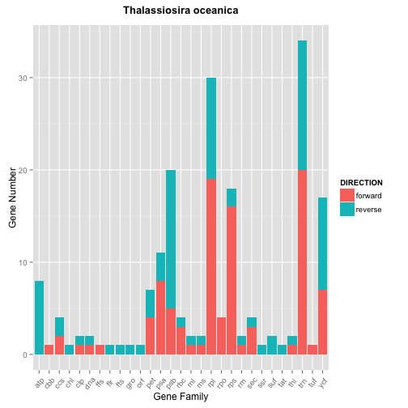

```r
source("../03 Visualizations/R3_figure1.R", echo = TRUE)
```

```
##
## > l_gf <- list()
##
## > ocean_g <- ggplot(data = ocean_gf, mapping = aes(x = gene_family)) +
## +     layer(geom = "bar", mapping = aes(fill = DIRECTION)) + labs(title = "Tha ..." ... [TRUNCATED]
##
## > ocean_g
```

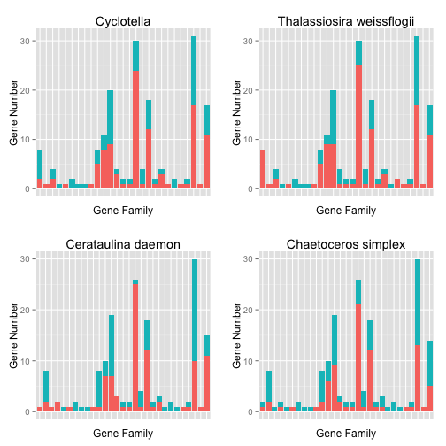

```
##
## > l_gf[[1]] <- ggplot(data = cyc_gf, mapping = aes(x = gene_family)) +
## +     layer(geom = "bar", mapping = aes(fill = DIRECTION)) + labs(title = "Cyc ..." ... [TRUNCATED]
##
## > l_gf[[2]] <- ggplot(data = weiss_gf, mapping = aes(x = gene_family)) +
## +     layer(geom = "bar", mapping = aes(fill = DIRECTION)) + labs(title = "T ..." ... [TRUNCATED]
##
## > l_gf[[3]] <- ggplot(data = cera_gf, mapping = aes(x = gene_family)) +
## +     layer(geom = "bar", mapping = aes(fill = DIRECTION)) + labs(title = "Ce ..." ... [TRUNCATED]
##
## > l_gf[[4]] <- ggplot(data = chaeto_gf, mapping = aes(x = gene_family)) +
## +     layer(geom = "bar", mapping = aes(fill = DIRECTION)) + labs(title = " ..." ... [TRUNCATED]
##
## > pushViewport(viewport(layout = grid.layout(2, 4)))
##
## > print(l_gf[[1]], vp = viewport(layout.pos.row = 1,
## +     layout.pos.col = 1:2))
##
## > print(l_gf[[2]], vp = viewport(layout.pos.row = 1,
## +     layout.pos.col = 3:4))
##
## > print(l_gf[[3]], vp = viewport(layout.pos.row = 2,
## +     layout.pos.col = 1:2))
##
## > print(l_gf[[4]], vp = viewport(layout.pos.row = 2,
## +     layout.pos.col = 3:4))
```

In this figure, the x axis indicates gene family, the y axis indicates gene number in that family. The red color indicates genes in forward direction (sense strand), and the blue color indicates genes in reverse direction (anti-sense strand).

From this figure, we can see that Cyclotella and Thalassiosira weissflogii has similar number of forward and reverse genes in each gene family, while Cerataulina and Chaetoceros showing different number of forward and reverse genes in each gene family.

**Figure 2: Comparison of number of genes in each gene family in forward and reverse direction** The number of genes in each gene family, using Cyclotella as an example.

```r
source("../03 Visualizations/cyc_total_pie.R", echo = TRUE)
```

```
##
## > cyc_total_pie <- ggplot(cyc_gf_num, aes(x = " ", y = total_gene_num,
## +     fill = gene_family)) + geom_bar(width = 1, stat = "identity") +
## +     c .... [TRUNCATED]
##
## > print(cyc_total_pie)
```

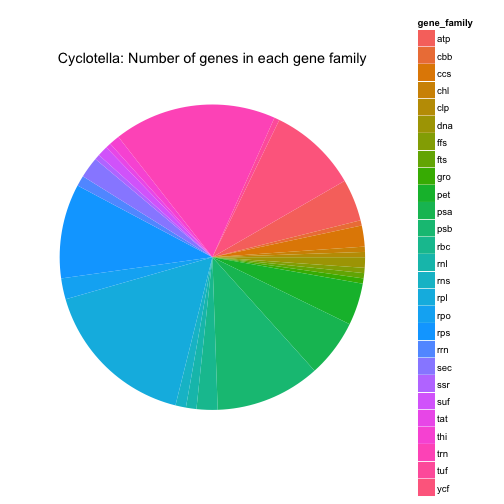

The number of forward genes in each gene family, and the number of reverse genes in each gene family.

```r
source("../03 Visualizations/pie_fr.R", echo = TRUE)
```

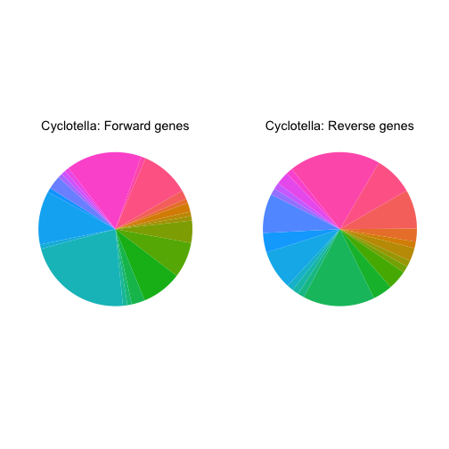

```
##
## > l_cyc_fr <- list()
##
## > l_cyc_fr[[1]] <- ggplot(cyc_gf_forwardNum, aes(x = " ",
## +     y = forward_gene_num, fill = gene_family)) + geom_bar(width = 1,
## +     stat = "ident ..." ... [TRUNCATED]
##
## > l_cyc_fr[[2]] <- ggplot(cyc_gf_reverseNum, aes(x = " ",
## +     y = reverse_gene_num, fill = gene_family)) + geom_bar(width = 1,
## +     stat = "ident ..." ... [TRUNCATED]
##
## > l_cyc_fr[[3]] <- ggplot(cyc_gf_num, aes(x = " ", y = total_gene_num,
## +     fill = gene_family)) + geom_bar(width = 1, stat = "identity") +
## +     c .... [TRUNCATED]
##
## > pushViewport(viewport(layout = grid.layout(1, 4)))
##
## > print(l_cyc_fr[[1]], vp = viewport(layout.pos.row = 1,
## +     layout.pos.col = 1:2))
##
## > print(l_cyc_fr[[2]], vp = viewport(layout.pos.row = 1,
## +     layout.pos.col = 3:4))
```

**Figure 3:Average Gene Length in Each Gene Family**

First, we reshape the data using gather(). Below we show the data frame before and after reshape

```r
source("../02 Data Wrangling/reshapeDF.R", echo = TRUE)
```

```
##
## > names(inner_df) <- c("gene_family", "cyc", "weiss",
## +     "ocean", "cera", "chaeto")
##
## > inner_df %>% tbl_df
## Source: local data frame [27 x 6]
##
##    gene_family     cyc   weiss     ocean   cera chaeto
## 1          atp  63.250  63.375  736.5000  66.50  65.75
## 2          cbb 112.000 110.000  864.0000 116.00 115.00
## 3          ccs  64.500  62.500 1122.0000  64.00  64.00
## 4          chl   1.000   2.000 1059.0000   3.00   4.00
## 5          clp  40.000  41.000 2799.0000  42.00  41.00
## 6          dna  13.500  13.500 1596.0000  15.00  15.50
## 7          ffs  21.000  22.000  100.0000  23.00  24.00
## 8          fts  20.000  20.000 1929.0000  21.00  22.00
## 9          gro  18.000  18.000 1593.0000  19.00  20.00
## 10         pet  80.125  78.375  357.8571  82.75  81.50
## ..         ...     ...     ...       ...    ...    ...
##
## > tidy_inner_df <- gather(inner_df, "species", "avg_length",
## +     2:6)
##
## > tidy_inner_df %>% tbl_df
## Source: local data frame [135 x 3]
##
##    gene_family species avg_length
## 1          atp     cyc     63.250
## 2          cbb     cyc    112.000
## 3          ccs     cyc     64.500
## 4          chl     cyc      1.000
## 5          clp     cyc     40.000
## 6          dna     cyc     13.500
## 7          ffs     cyc     21.000
## 8          fts     cyc     20.000
## 9          gro     cyc     18.000
## 10         pet     cyc     80.125
## ..         ...     ...        ...
```

We produced a bubble plot demenostrating the average gene length in each gene family for 4 different diatom species.

```r
source("../03 Visualizations/joinFigure.R", echo = TRUE)
```

```
##
## > sub_df <- tidy_inner_df %>% filter(species %in% c("weiss",
## +     "cyc", "cera", "chaeto"))
##
## > g <- ggplot(sub_df, aes(x = gene_family, y = avg_length,
## +     size = species, color = species)) + geom_point() + ggtitle("Average gene length of \ ..." ... [TRUNCATED]
##
## > g
```

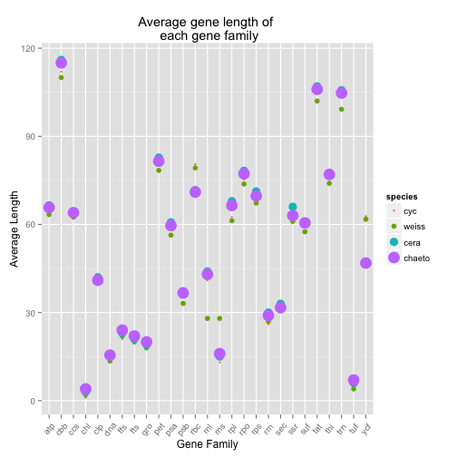

**Figure 4: Histogram from non-categorical data**

```r
source("../01 Data/categorical.R", echo = TRUE)
```

```
##
## > categoricals <- eval(parse(text = substring(getURL(URLencode("http://129.152.144.84:5001/rest/native/?query=\"select * from ocean\""),
## +     httphe .... [TRUNCATED]
##
## > categoricals
## [[1]]
## [[1]][[1]]
## [1] "NAME"
##
## [[1]][[2]]
## [1] "DIRECTION"
##
##
## [[2]]
## [[2]][[1]]
## [1] "START_POS"
##
## [[2]][[2]]
## [1] "END_POS"
##
## [[2]][[3]]
## [1] "LENGTH"
```

```
##
## > myplot1 <- function(df, x) {
## +     names(df) <- c("x")
## +     ggplot(df, aes(x = x)) + geom_histogram()
## + }
##
## > l_hist <- list()
##
## > for (i in names(ocean)) {
## +     if (i %in% categoricals[[2]]) {
## +         r <- data.frame(fromJSON(getURL(URLencode("129.152.144.84:5001/rest/native ..." ... [TRUNCATED]
##
## > startFig <- l_hist[[1]] + ggtitle("Codon Start Position") +
## +     geom_histogram(aes(fill = ..count..)) + theme(legend.position = "none",
## +     ax .... [TRUNCATED]
##
## > endFig <- l_hist[[2]] + ggtitle("Codon End Position") +
## +     geom_histogram(aes(fill = ..count..)) + theme(legend.position = "none",
## +     axis.t .... [TRUNCATED]
##
## > lenFig <- l_hist[[3]] + ggtitle("Gene Length") + geom_histogram(aes(fill = ..count..)) +
## +     theme(axis.text.x = element_text(angle = 50, vjust = .... [TRUNCATED]
##
## > pushViewport(viewport(layout = grid.layout(5, 4)))
##
## > print(startFig, vp = viewport(layout.pos.row = 1:2,
## +     layout.pos.col = 1:2))
```

```
## stat_bin: binwidth defaulted to range/30. Use 'binwidth = x' to adjust this.
## stat_bin: binwidth defaulted to range/30. Use 'binwidth = x' to adjust this.
```

```
##
## > print(endFig, vp = viewport(layout.pos.row = 1:2,
## +     layout.pos.col = 3:4))
```

```
## stat_bin: binwidth defaulted to range/30. Use 'binwidth = x' to adjust this.
## stat_bin: binwidth defaulted to range/30. Use 'binwidth = x' to adjust this.
```

```
##
## > print(lenFig, vp = viewport(layout.pos.row = 3:5,
## +     layout.pos.col = 1:4))
```

```
## stat_bin: binwidth defaulted to range/30. Use 'binwidth = x' to adjust this.
## stat_bin: binwidth defaulted to range/30. Use 'binwidth = x' to adjust this.
```

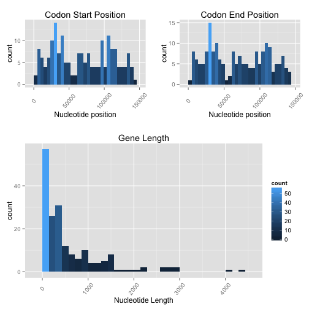

```r
source("../03 Visualizations/histogram.R", echo = TRUE)
```